# Lab 4: Childcare Costs in California

- Show All Code
- Hide All Code
- View Source

Author

Jonathan Howo

# Part One: Set-up

In this lab, we will be using the **tidyr** and **forcats** packages to explore the cost of childcare across the US. **You are expected to use functions from tidyr and forcats to do your data manipulation!**

# Exploring Childcare Costs

## The Data

In this lab we’re going look at the median weekly cost of childcare in California. The data come to us from [TidyTuesday](https://github.com/rfordatascience/tidytuesday). A detailed description of the data can be found [here](https://github.com/rfordatascience/tidytuesday/blob/master/data/2023/2023-05-09/readme.md). **You will need to use this data dictionary to complete the lab!**

We also have information from the California State Controller on tax revenue for california counties from 2005 - 2018. I compiled the data from [this website](https://counties.bythenumbers.sco.ca.gov/#!/year/default) for you. Note that there is no data for San Franscisco County. The variables included in the `ca_tax_revenue.csv` data file (loaded below) include:

- `entity_name`: County name
- `year`: fiscal year
- `total_property_taxes`: total revenue in $ from property taxes
- `sales_and_use_taxes`: total revenue in $ from sales and use taxes

**0. Load the appropriate libraries and the data.**

```r
library(tidyverse)
```

```r
childcare_costs <- read_csv('https://raw.githubusercontent.com/rfordatascience/tidytuesday/master/data/2023/2023-05-09/childcare_costs.csv')

counties <- read_csv('https://raw.githubusercontent.com/rfordatascience/tidytuesday/master/data/2023/2023-05-09/counties.csv')

tax_rev <- read_csv('https://atheobold.github.io/groupworthy-data-science/labs/instructions/data/ca_tax_revenue.csv')
```

**1. Briefly describe the `childcare_costs` dataset (~ 4 sentences). What information does it contain?** The childcare_costs dataset comes from the National Database of Childcare Prices. The dataset has 61 columns and about 35,000 rows. It has numeric data regarding information about childcare price data by childcare provider type, age of children, and county characteristics. The dataset has data from 2008 - 2018.

```r
glimpse(childcare_costs)
```

```
Rows: 34,567
Columns: 61
$ county_fips_code          <dbl> 1001, 1001, 1001, 1001, 1001, 1001, 1001, 10…
$ study_year                <dbl> 2008, 2009, 2010, 2011, 2012, 2013, 2014, 20…
$ unr_16                    <dbl> 5.42, 5.93, 6.21, 7.55, 8.60, 9.39, 8.50, 7.…
$ funr_16                   <dbl> 4.41, 5.72, 5.57, 8.13, 8.88, 10.31, 9.18, 8…
$ munr_16                   <dbl> 6.32, 6.11, 6.78, 7.03, 8.29, 8.56, 7.95, 6.…
$ unr_20to64                <dbl> 4.6, 4.8, 5.1, 6.2, 6.7, 7.3, 6.8, 5.9, 4.4,…
$ funr_20to64               <dbl> 3.5, 4.6, 4.6, 6.3, 6.4, 7.6, 6.8, 6.1, 4.6,…
$ munr_20to64               <dbl> 5.6, 5.0, 5.6, 6.1, 7.0, 7.0, 6.8, 5.9, 4.3,…
$ flfpr_20to64              <dbl> 68.9, 70.8, 71.3, 70.2, 70.6, 70.7, 69.9, 68…
$ flfpr_20to64_under6       <dbl> 66.9, 63.7, 67.0, 66.5, 67.1, 67.5, 65.2, 66…
$ flfpr_20to64_6to17        <dbl> 79.59, 78.41, 78.15, 77.62, 76.31, 75.91, 75…
$ flfpr_20to64_under6_6to17 <dbl> 60.81, 59.91, 59.71, 59.31, 58.30, 58.00, 57…
$ mlfpr_20to64              <dbl> 84.0, 86.2, 85.8, 85.7, 85.7, 85.0, 84.2, 82…
```

[output cut: 48 more lines]

```r
glimpse(counties)
```

```
Rows: 3,144
Columns: 4
$ county_fips_code   <dbl> 1001, 1003, 1005, 1007, 1009, 1011, 1013, 1015, 101…
$ county_name        <chr> "Autauga County", "Baldwin County", "Barbour County…
$ state_name         <chr> "Alabama", "Alabama", "Alabama", "Alabama", "Alabam…
$ state_abbreviation <chr> "AL", "AL", "AL", "AL", "AL", "AL", "AL", "AL", "AL…
```

```r
glimpse(tax_rev)
```

```
Rows: 798
Columns: 4
$ entity_name          <chr> "Alameda County", "Alameda County", "Alameda Coun…
$ year                 <dbl> 2005, 2006, 2007, 2008, 2009, 2010, 2011, 2012, 2…
$ total_property_taxes <dbl> 345526482, 417893373, 449671803, 479817783, 49086…
$ sales_and_use_taxes  <dbl> 13564326, 15201263, 18566445, 14375709, 12690017,…
```

## California Childcare Costs

**2. Let’s start by focusing only on California. Create a `ca_childcare` dataset of childcare costs in California, containing (1) county information and (2) all information from the `childcare_costs` dataset. You should do all of this within one pipeline.**

```r
ca_childcare <- childcare_costs |>
  left_join(y = counties,
            by = join_by(county_fips_code)
            ) |>
  filter(state_abbreviation == "CA")
ca_childcare
```

```
# A tibble: 638 × 64
   county_fips_code study_year unr_16 funr_16 munr_16 unr_20to64 funr_20to64
              <dbl>      <dbl>  <dbl>   <dbl>   <dbl>      <dbl>       <dbl>
 1             6001       2008   6.6     6.57    6.63        6.1         6.1
 2             6001       2009   7.71    7.53    7.86        7.2         7.1
 3             6001       2010   8.5     8.24    8.73        7.9         7.7
 4             6001       2011   9.21    8.87    9.51        8.7         8.4
 5             6001       2012   9.91    9.68   10.1         9.3         9.2
 6             6001       2013  10.3    10.2    10.5         9.7         9.6
 7             6001       2014   9.6     9.59    9.58        9           9.1
 8             6001       2015   8.26    8.44    8.11        7.8         8
 9             6001       2016   7.11    7.34    6.91        6.7         7
10             6001       2017   6.05    6.06    6.03        5.7         5.7
# ℹ 628 more rows
# ℹ 57 more variables: munr_20to64 <dbl>, flfpr_20to64 <dbl>,
#   flfpr_20to64_under6 <dbl>, flfpr_20to64_6to17 <dbl>,
#   flfpr_20to64_under6_6to17 <dbl>, mlfpr_20to64 <dbl>, pr_f <dbl>,
#   pr_p <dbl>, mhi_2018 <dbl>, me_2018 <dbl>, fme_2018 <dbl>, mme_2018 <dbl>,
#   total_pop <dbl>, one_race <dbl>, one_race_w <dbl>, one_race_b <dbl>,
#   one_race_i <dbl>, one_race_a <dbl>, one_race_h <dbl>, …
```

**3. Now, lets add the tax revenue information to the `ca_childcare` dataset. Add the data from `tax_rev` for the counties and years that are already in the `ca_childcare` data. Overwrite the old `ca_childcare` data with this dataset.**

```r
ca_childcare <-ca_childcare |>
  left_join(y = tax_rev,
            by = join_by(county_name == entity_name, study_year == year)
            )
ca_childcare
```

```
# A tibble: 638 × 66
   county_fips_code study_year unr_16 funr_16 munr_16 unr_20to64 funr_20to64
              <dbl>      <dbl>  <dbl>   <dbl>   <dbl>      <dbl>       <dbl>
 1             6001       2008   6.6     6.57    6.63        6.1         6.1
 2             6001       2009   7.71    7.53    7.86        7.2         7.1
 3             6001       2010   8.5     8.24    8.73        7.9         7.7
 4             6001       2011   9.21    8.87    9.51        8.7         8.4
 5             6001       2012   9.91    9.68   10.1         9.3         9.2
 6             6001       2013  10.3    10.2    10.5         9.7         9.6
 7             6001       2014   9.6     9.59    9.58        9           9.1
 8             6001       2015   8.26    8.44    8.11        7.8         8
 9             6001       2016   7.11    7.34    6.91        6.7         7
10             6001       2017   6.05    6.06    6.03        5.7         5.7
# ℹ 628 more rows
# ℹ 59 more variables: munr_20to64 <dbl>, flfpr_20to64 <dbl>,
#   flfpr_20to64_under6 <dbl>, flfpr_20to64_6to17 <dbl>,
#   flfpr_20to64_under6_6to17 <dbl>, mlfpr_20to64 <dbl>, pr_f <dbl>,
#   pr_p <dbl>, mhi_2018 <dbl>, me_2018 <dbl>, fme_2018 <dbl>, mme_2018 <dbl>,
#   total_pop <dbl>, one_race <dbl>, one_race_w <dbl>, one_race_b <dbl>,
#   one_race_i <dbl>, one_race_a <dbl>, one_race_h <dbl>, …
```

**4. Using a function from the `forcats` package, complete the code below to create a new variable where each county is categorized into one of the [ten (10) Census regions](https://census.ca.gov/regions/) in California. Use the Region description (from the plot), not the Region number.** The code below will help you get started.

```r
superior_counties <- c("Butte","Colusa","El Dorado",
                       "Glenn","Lassen","Modoc",
                       "Nevada","Placer","Plumas",
                       "Sacramento","Shasta","Sierra","Siskiyou",
                       "Sutter","Tehama","Yolo","Yuba")

north_coast_counties <- c("Del Norte","Humboldt","Lake",
                          "Mendocino","Napa","Sonoma","Trinity")

san_fran_counties <- c("Alameda","Contra Costa","Marin",
                       "San Francisco","San Mateo","Santa Clara",
                       "Solano")

n_san_joaquin_counties <- c("Alpine","Amador","Calaveras","Madera",
                            "Mariposa","Merced","Mono","San Joaquin",
                            "Stanislaus","Tuolumne")

central_coast_counties <- c("Monterey","San Benito","San Luis Obispo",
                            "Santa Barbara","Santa Cruz","Ventura")

s_san_joaquin_counties <- c("Fresno","Inyo","Kern","Kings","Tulare")

inland_counties <- c("Riverside","San Bernardino")

la_county <- "Los Angeles"

orange_county  <- "Orange"

san_diego_imperial_counties <- c("Imperial","San Diego")
```

```r
# Finish this code using the census regions defined above

ca_childcare <- ca_childcare |>
  mutate(county_name = str_remove(county_name, " County")) |>
  mutate(county_name = as_factor(county_name)) |>
  mutate(region = fct_collapse(
    county_name,
    "Superior California" = superior_counties,
    "North Coast" = north_coast_counties,
    "San Francisco Bay Area" = san_fran_counties,
    "Northern San Joaquin Valley" = n_san_joaquin_counties,
    "Central Coast" = central_coast_counties,
    "Southern San Joaquin Valley" = s_san_joaquin_counties,
    "Inland Empire" = inland_counties,
    "Los Angeles" = la_county,
    "Orange County" = orange_county,
    "San Diego-Imperial" = san_diego_imperial_counties
  ))
ca_childcare
```

```
# A tibble: 638 × 67
   county_fips_code study_year unr_16 funr_16 munr_16 unr_20to64 funr_20to64
              <dbl>      <dbl>  <dbl>   <dbl>   <dbl>      <dbl>       <dbl>
 1             6001       2008   6.6     6.57    6.63        6.1         6.1
 2             6001       2009   7.71    7.53    7.86        7.2         7.1
 3             6001       2010   8.5     8.24    8.73        7.9         7.7
 4             6001       2011   9.21    8.87    9.51        8.7         8.4
 5             6001       2012   9.91    9.68   10.1         9.3         9.2
 6             6001       2013  10.3    10.2    10.5         9.7         9.6
 7             6001       2014   9.6     9.59    9.58        9           9.1
 8             6001       2015   8.26    8.44    8.11        7.8         8
 9             6001       2016   7.11    7.34    6.91        6.7         7
10             6001       2017   6.05    6.06    6.03        5.7         5.7
# ℹ 628 more rows
# ℹ 60 more variables: munr_20to64 <dbl>, flfpr_20to64 <dbl>,
#   flfpr_20to64_under6 <dbl>, flfpr_20to64_6to17 <dbl>,
#   flfpr_20to64_under6_6to17 <dbl>, mlfpr_20to64 <dbl>, pr_f <dbl>,
#   pr_p <dbl>, mhi_2018 <dbl>, me_2018 <dbl>, fme_2018 <dbl>, mme_2018 <dbl>,
#   total_pop <dbl>, one_race <dbl>, one_race_w <dbl>, one_race_b <dbl>,
#   one_race_i <dbl>, one_race_a <dbl>, one_race_h <dbl>, …
```

**5. Let’s consider the median household income of each region, and how that income has changed over time. Create a table with ten rows, one for each region, and two columns, one for 2008 and one for 2018 (plus a column for region). The cells should contain the `median()` of the median household income (expressed in 2018 dollars) of the `region` and the `study_year`. Order the rows by 2018 values from highest income to lowest income.**

```r
median_region_income <- ca_childcare |>
  select(region, study_year, mhi_2018) |>
  group_by(region, study_year) |>
  summarize(median_income = median(mhi_2018, na.rm =TRUE)) |>
  ungroup() |>

  pivot_wider(
    names_from = study_year,
    values_from = median_income,
    names_prefix = "income_"
  ) |>
  arrange(desc(income_2018))

median_region_income
```

```
# A tibble: 10 × 12
   region            income_2008 income_2009 income_2010 income_2011 income_2012
   <fct>                   <dbl>       <dbl>       <dbl>       <dbl>       <dbl>
 1 San Francisco Ba…      90412.      91070.      90927.      88631.      86006.
 2 Orange County          86452.      86273.      86239.      84853.      83123.
 3 Central Coast          72979       72565.      72692.      71381.      69664.
 4 Los Angeles            63471.      64149.      64352.      63018.      61865.
 5 Inland Empire          65977.      66465.      65896.      63962.      61515.
 6 San Diego-Imperi…      58201.      58790.      59017.      57825.      57545.
 7 Northern San Joa…      59108.      60547.      61152.      58484.      58325.
 8 Superior Califor…      57831.      55166.      55699.      55505.      51305.
 9 Southern San Joa…      52676.      54073.      53859.      53784.      50315.
10 North Coast            47862.      48183.      46503.      45221.      44913
# ℹ 6 more variables: income_2013 <dbl>, income_2014 <dbl>, income_2015 <dbl>,
#   income_2016 <dbl>, income_2017 <dbl>, income_2018 <dbl>
```

**6. Which California `region` had the lowest `median` full-time median weekly price for center-based childcare for infants in 2018? Does this `region` correspond to the `region` with the lowest `median` income in 2018 that you found in Q4?**

This region does not correspond to the region with the lowest median income in 2018 that I foudn in Q4. The lowest ‘median’ full-time median weekly price for center based childcare for infants in 2018 is Superior California.

```r
lowest_weekly_price_region <- ca_childcare |>
  filter(study_year == 2018) |>
  group_by(region) |>
  summarize(median_weekly_price = median(mc_infant, na.rm =TRUE)) |>
  arrange(median_weekly_price) |>
  slice(1)

lowest_weekly_price_region
```

```
# A tibble: 1 × 2
  region              median_weekly_price
  <fct>                             <dbl>
1 Superior California                215.
```

**7. The following plot shows, for all ten regions, the change over time of the full-time median price for center-based childcare for infants, toddlers, and preschoolers. Recreate the plot. You do not have to replicate the exact colors or theme, but your plot should have the same content, including the order of the facets and legend, reader-friendly labels, axes breaks, and a loess smoother.**

Plot to recreate

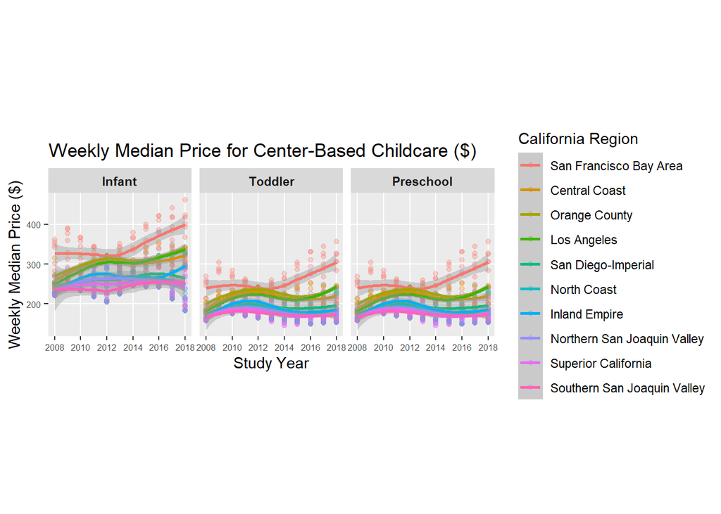

```r
ca_childcare_2 <- ca_childcare |>
  select(county_name, region, study_year,
         mc_infant, mc_toddler, mc_preschool) |>
  pivot_longer(
    cols = starts_with("mc_"),
    names_to = "age_group",
    values_to = "weekly_center_based_childcare_cost"
  ) |>
  mutate(
    age_group = recode(age_group,
                       mc_infant = "Infant",
                       mc_toddler = "Toddler",
                       mc_preschool = "Preschool") |>
         factor(levels = c("Infant", "Toddler", "Preschool")),
    region = fct_reorder(region, weekly_center_based_childcare_cost, median, .desc = TRUE)
  )

ggplot(
  data = ca_childcare_2,
  aes(
    x = study_year,
    y = weekly_center_based_childcare_cost,
    color = region
  )) +
  geom_point(alpha = 0.3) +
  geom_smooth(method = "loess", se = TRUE) +
  facet_wrap(~ age_group, ncol = 3) +
  labs(
    title = "Weekly Median Price for Center-Based Childcare ($)",
    x = "Study Year",
    y = "Weekly Median Price ($)",
    color = "California Region"
  ) +
  scale_x_continuous(breaks = seq(2008, 2018, 2)) +
  theme(
    aspect.ratio = 1,
    axis.text = element_text(size = 6),
    legend.position = "right",
    panel.grid.minor = element_blank(),
    strip.text = element_text(face = "bold")
  )
```

## Median Household Income vs. Childcare Costs for Infants

**8. Create a scatterplot showing the relationship between median household income (expressed in 2018 dollars) and the full-time median weekly price charged for center-based childcare for an infant in California. Overlay a linear regression line (lm) to show the trend.**

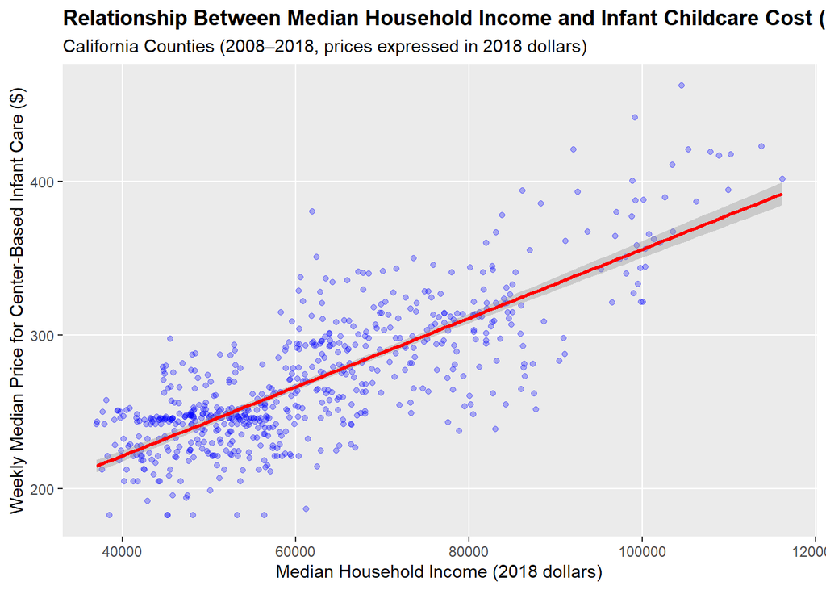

```r
ca_childcare |>
  select(county_name, region, study_year, mhi_2018, mc_infant) |>

  ggplot(
    aes(
      x = mhi_2018,
      y = mc_infant
    )) +
  geom_point(alpha = 0.3, color = "blue") +
  geom_smooth(method = "lm", se = TRUE, color = "red") +
  labs(
    title = "Relationship Between Median Household Income and Infant Childcare Cost (Center-Based)",
    subtitle = "California Counties (2008–2018, prices expressed in 2018 dollars)",
    x = "Median Household Income (2018 dollars)",
    y = "Weekly Median Price for Center-Based Infant Care ($)"
  ) +
  theme(
    plot.title = element_text(face = "bold"),
    panel.grid.minor = element_blank()
  )
```

**9. Look up the documentation for `lm()` and fit a linear regression model to the relationship shown in your plot above.**

```r
# complete the code provided
reg_mod1 <- lm(mc_infant ~ mhi_2018,
               data = ca_childcare)
summary(reg_mod1)
```

```
Call:
lm(formula = mc_infant ~ mhi_2018, data = ca_childcare)

Residuals:
    Min      1Q  Median      3Q     Max
-82.407 -15.606   0.097  15.999 110.026

Coefficients:
             Estimate Std. Error t value Pr(>|t|)
(Intercept) 1.317e+02  4.321e+00   30.49   <2e-16 ***
mhi_2018    2.241e-03  6.737e-05   33.26   <2e-16 ***
---
Signif. codes:  0 '***' 0.001 '**' 0.01 '*' 0.05 '.' 0.1 ' ' 1

Residual standard error: 27.48 on 636 degrees of freedom
Multiple R-squared:  0.635, Adjusted R-squared:  0.6344
F-statistic:  1106 on 1 and 636 DF,  p-value: < 2.2e-16
```

**10. Using the output from `summary()`, write out the estimated regression line (recall: $y = mx + b$).**

Estimated regression line model: y = 0.002241x +131.7

**11. Do you have evidence to conclude there is a relationship between the median household income and the median weekly cost of center-based childcare for infants in California? Cite values from your `summary()` output to support your claim!**

Yes, there is a relationship between the median household income and the median weekly cost of center-based childcare for infants in Californina. From the linear regression model ouput, the slope coefficent for income is a positive 0.002241 meaning higher income areas tend to have higher infant childcare prices. Additionally, the t-value is 33.26, shows that the slope is 33 standard errors away from zero, and with a p-value of <2e-16, which means the relationship is statistically significant as it is beyond significant level 0.05.